# Philadelphia Eviction Forecasting Model

Predicting Tract-Level Eviction Risk for Targeted Rental Assistance

Daisy, Gab, Johnny, Yiting

2026-04-28

## The Policy Problem

- Eviction filings are not evenly distributed across Philadelphia.
- Limited rental assistance resources require a way to identify where preventive intervention may be most needed.  
  **This project asks whether eviction filing data can help identify high-risk census tracts before housing instability worsens.**

## Research Question

Can recent eviction filing patterns help predict future eviction risk across Philadelphia census tracts?  
We focus on three questions:  
- Which tracts show persistent high filing activity?  
- Does monthly or quarterly prediction work better?  
- Can the model support rental assistance targeting?

## Data and Study Design

| Component | Description |
| --- | --- |
| Outcome | Eviction filings |
| Geography | Philadelphia tracts |
| Period | Mar 2023–Mar 2026 |
| Predictors | Filing history, ACS housing variables |
| Task | Predict next month / quarter |
| Use | Target rental assistance |

## Post-Pandemic Filings Offer a More Stable Modeling Window

**The model needs a stable policy environment.**

- Pandemic-era filing patterns were highly disrupted.
- March 2023 onward shows more consistent monthly variation.
- This period better reflects current eviction risk.
- We use this period to train a more comparable forecasting model.

## Monthly Filings Stabilize After Pandemic Disruption

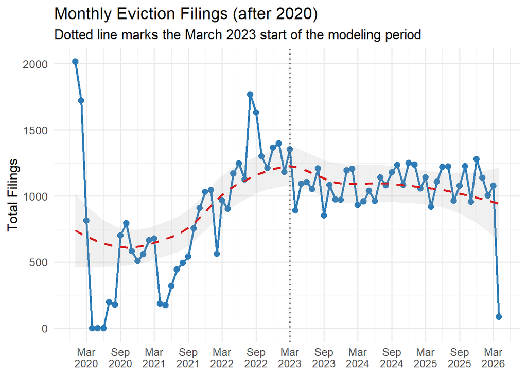

## Eviction Filings Are Highly Skewed

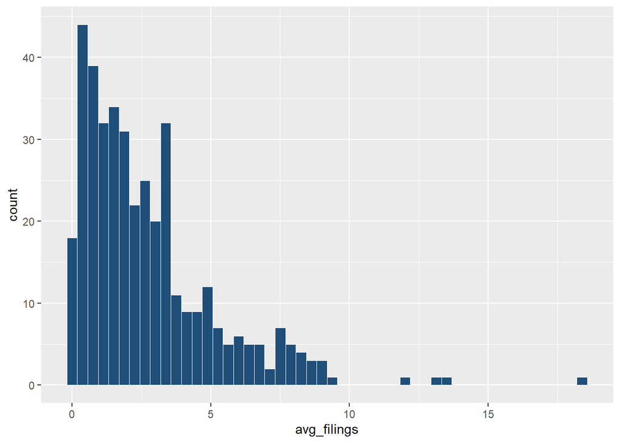

## Spatial Patterns of Eviction Risk

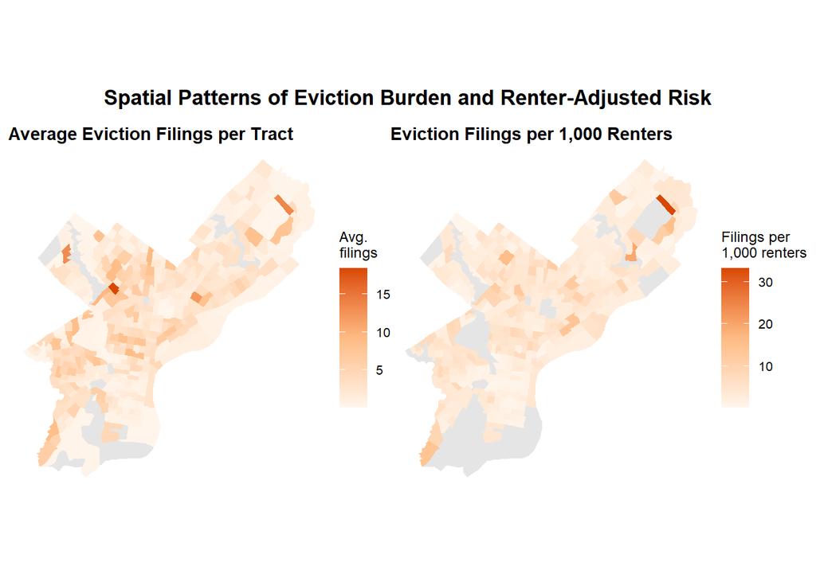

## Spatial Hotspots Point to Stronger Assistance Targets

- Eviction burden is not evenly distributed across Philadelphia.
- Raw filing counts show where total eviction activity is highest.
- Renter-adjusted rates show where eviction risk is most concentrated.
- Tracts high on both measures are stronger candidates for rental assistance targeting.

## Eviction Risk and Neighborhood Demographics

| Tract racial majority | Avg. monthly filings |
| --- | --- |
| Black | 3.80 |
| Hispanic | 2.63 |
| Other | 2.60 |
| White | 1.70 |

## Structural Housing Inequality

- Black-majority tracts show higher average eviction filing levels.
- Hispanic-majority and other-majority tracts also show higher filings than white-majority tracts.
- These patterns suggest eviction risk reflects broader structural disparities in housing stability.
- Model outputs should be interpreted with equity safeguards.

## Modeling Strategy

We test whether recent filing history can predict future tract-level eviction risk.

- **Monthly model:** predicts next-month eviction filings.
- **Quarterly model:** predicts next-quarter eviction filings.
- **Key predictors:** lagged filings, rolling averages, historical baselines, and ACS housing variables.
- **Evaluation:** prediction error, tract ranking, and high-risk classification.

## Monthly vs. Quarterly Forecasting

We compare two forecasting scales because they serve different policy needs.

### Monthly

- Shorter intervention window
- More sensitive to recent changes
- Better for rapid outreach
- More month-to-month noise

### Quarterly

- Smoother filing patterns
- Better for broader planning
- Less reactive to sudden spikes
- Longer delay before intervention

## Model Performance Summary

| Model | Scale | Test MAE | Test RMSE | Correlation |
| --- | --- | --- | --- | --- |
| Rolling baseline | Monthly | 1.657 | 2.441 | 0.678 |
| Baseline | Quarterly | 3.718 | 5.422 | 0.779 |

## Rolling Monthly Baseline Has the Lowest Error

| Criterion | Best model | Scale | MAE | RMSE | Correlation |
| --- | --- | --- | --- | --- | --- |
| Lowest error | Rolling monthly baseline | Monthly | 1.657 | 2.441 | 0.678 |
| Strongest ranking | Quarterly temporal baseline | Quarterly | 3.718 | 5.422 | 0.779 |
| Richer covariates | Monthly NB covariates | Monthly | 2.137 | 4.265 | 0.594 |

## Model Performance Summary

- Recent filing history is highly predictive.
- Simple temporal baselines perform better than more complex models.
- Adding more structural covariates does not always improve out-of-sample accuracy.
- Monthly prediction is more useful for short-term intervention planning.

## Monthly Forecasts Better Match Time-Sensitive Outreach

- Rental assistance is often time-sensitive.
- Monthly forecasts identify risk closer to when filings may occur.
- Recent filing history and rolling averages capture short-term persistence.
- This makes monthly prediction better suited for early outreach and prevention.

## Monthly Model Diagnostics

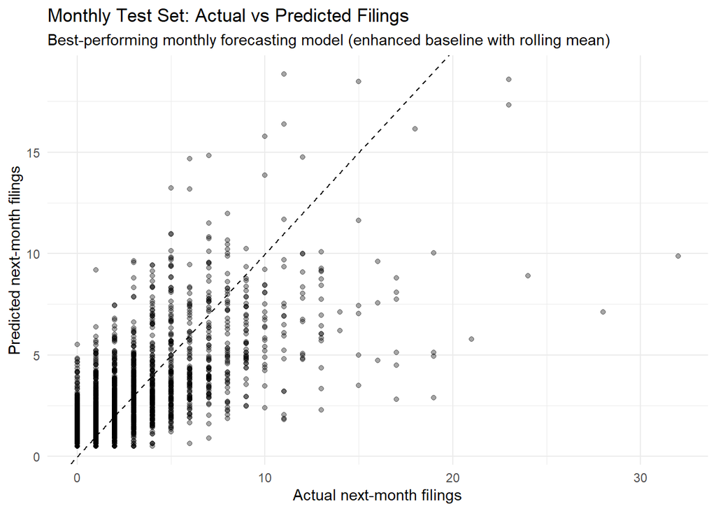

## The Model Captures Patterns but Misses Extremes

- Predictions follow the general tract-level pattern.
- The model compresses the upper tail of high-filing tracts.
- Extreme filing spikes remain difficult to predict.
- This supports using the model as a screening tool, not an automatic decision rule.

## Quarterly Model Diagnostics

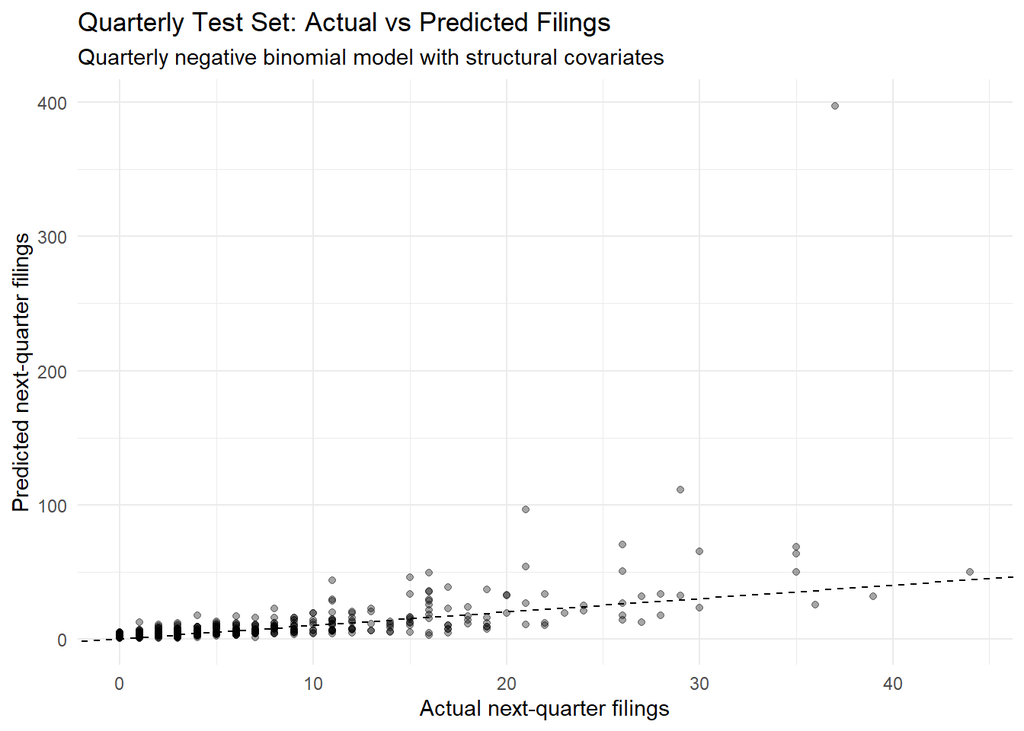

## Quarterly Model Trade off

Quarterly aggregation smooths short-term noise, but it can hide sudden tract-level changes.

- Quarterly predictions are less sensitive to monthly volatility.
- This can help with general planning.
- But the model struggles with extreme high-filing tracts.
- For targeted rental assistance, this delay can be costly.

## Policy Application

The model is most useful as an early-warning and prioritization tool.

- Identify tracts with elevated predicted filing risk.
- Prioritize outreach before filings escalate.
- Support rental assistance targeting at the neighborhood level.
- Combine model output with local knowledge and equity review.

**The model should support policy judgment, not replace it.**

## Key Takeaways

1. Eviction filings in Philadelphia are spatially concentrated and structurally uneven.
2. Recent filing history is the strongest short-term predictor of future filings.
3. Forecasting models can help target rental assistance, but should be used with equity checks and policy judgment.

## Conclusion

**Eviction risk is predictable enough to support early intervention, but not predictable enough to automate policy decisions.**

A short-term forecasting model can help Philadelphia identify elevated-risk tracts and prioritize rental assistance outreach.

Its strongest use is not replacing human judgment, but making policy response faster, more targeted, and more transparent.

## Thank You！

**Questions and Discussion ？**

Daisy, Gab, Johnny, Yiting

*CPLN 5920 | Philadelphia Eviction Forecasting Model*